# Approaches based on CIF specification

Karla Monterrubio-Gómez, Nathan Constantine-Cooke, and Catalina Vallejos

2022-11-15

# Dataset

In order to demonstrate the methods, we employ publicly available data.

The dataset used here corresponds to the Hodgkin’s disease (HD) study described in Pintilie (2006). The dataset comprises 865 patients diagnosed with early stage (I or II) HD, and which were treated either with radiation (RT) or with radiation and chemotherapy (CMT).

The recorded data includes:

- age: Age (years)
- sex: Sex, F=female and M=Male.
- trtgiven: Treatment given, RT=Radiation, CMT=Chemotherapy and radiation
- medwidsi: Size of mediastinum involvement, N=No, S=Small, L=Large
- extranod: Extranodal disease, Y=Extranodal disease, N= Nodal disease
- clinstg: Clinical stage, 1=Stage I, 2=Stage II
- time: time to failure (years) calculated from the date of diagnosis
- status: 0=censoring, 1=relapse and 2=death.

We now load and display the structure of the HD dataset:

```r
library(readr)
hd <- data.frame(read_csv("../Data/HD/hd.csv",
                          col_types = cols(X1 = col_skip())))
str(hd)
```

```
#> 'data.frame':    865 obs. of  9 variables:
#>  $ ...1    : num  1 2 3 4 5 6 7 8 9 10 ...
#>  $ age     : num  64 63 17 63 21 37 41 35 27 32 ...
#>  $ sex     : chr  "F" "M" "M" "M" ...
#>  $ trtgiven: chr  "RT" "RT" "RT" "RT" ...
#>  $ medwidsi: chr  "N" "N" "N" "N" ...
#>  $ extranod: chr  "N" "N" "N" "N" ...
#>  $ clinstg : num  1 1 2 2 2 1 2 2 2 2 ...
#>  $ time    : num  3.1 15.9 0.9 13.1 35.9 1.1 2.5 0.003 4.1 28.1 ...
#>  $ status  : num  2 2 1 2 0 1 1 1 1 0 ...
```

To proceed with the analysis, it is important to change the data type of sex, trtgiven, medwidsi, and extranod from character to factor. Similarly, we convert clinstg from numeric to factor.

```r
hd$sex      <- as.factor(hd$sex)
hd$trtgiven <- as.factor(hd$trtgiven)
hd$medwidsi <- as.factor(hd$medwidsi)
hd$extranod <- as.factor(hd$extranod)
hd$clinstg  <- as.factor(hd$clinstg)
```

Now, we explore the number of events for each event type:

```r
require(pander)
pander::pander(table(hd$status))
```

| 0 | 1 | 2 |
| --- | --- | --- |
| 439 | 291 | 135 |

In order to create a test set, we use stratified sampling to partition our dataset into 80% for train and 20% for test.

```r
library(splitstackshape)
set.seed(2022)
split_data <- stratified(hd, c("status"), 0.8, bothSets = TRUE)
hd_train   <- split_data$SAMP1
hd_test    <- split_data$SAMP2
```

Now, we explore the number of observations per status in both train and test set:

```r
pander::pander(table(hd_train$status))
```

| 0 | 1 | 2 |
| --- | --- | --- |
| 351 | 233 | 108 |

```r
pander::pander(table(hd_test$status))
```

| 0 | 1 | 2 |
| --- | --- | --- |
| 88 | 58 | 27 |

# Fine-Gray

In contrast to models that use a cause-specific CPH specification, this approach permits inferences for the covariate effects on both the hazard function and the survival function due to the fact that competing events are treated differently.

As with cause-specific CPH models, there are several R packages to fit a sub-distribution hazards model. Here we explore `cmprsk` and `riskRegression`.

## `cmprsk`

In order to fit the model, one should first create a design matrix containing the covariates of interest, this can be done employing the `model.matrix()` function, which creates dummy variables for the discrete predictors.

```r
library(cmprsk)
predictors <- model.matrix(~ age +
                             sex +
                             trtgiven +
                             medwidsi +
                             extranod +
                             clinstg,
                           data = hd_train)
head(predictors)
```

```
#>   (Intercept)   age sexM trtgivenRT medwidsiN medwidsiS extranodY clinstg2
#> 1           1 55.00    1          1         1         0         0        0
#> 2           1 51.00    1          1         0         1         1        0
#> 3           1 19.00    1          1         1         0         0        0
#> 4           1 52.23    1          0         1         0         0        1
#> 5           1 41.00    0          1         1         0         0        1
#> 6           1 25.00    0          1         1         0         0        0
```

Note that our covariates now correspond to binary indicators (1 or 0) of a specific level of the original factor variables. In order to use this design matrix, we will first drop the intercept. Once that has been done, we can employ the `crr()` function to fit the model.

```r
predictors <-  predictors[, -1] # drop first column (intercept)


FG_crr <- crr(ftime = hd_train$time,
              fstatus = hd_train$status,
              cov1 = predictors, # for time interactions use argument cov2
              failcode = 1,
              cencode = 0)
summary(FG_crr)
```

```
#> Competing Risks Regression
#>
#> Call:
#> crr(ftime = hd_train$time, fstatus = hd_train$status, cov1 = predictors,
#>     failcode = 1, cencode = 0)
#>
#>               coef exp(coef) se(coef)      z p-value
#> age         0.0136     1.014  0.00436  3.109 0.00190
#> sexM        0.0705     1.073  0.13587  0.519 0.60000
#> trtgivenRT  0.7030     2.020  0.20557  3.419 0.00063
#> medwidsiN  -0.0594     0.942  0.25960 -0.229 0.82000
#> medwidsiS  -0.4029     0.668  0.25558 -1.577 0.11000
#> extranodY   0.3162     1.372  0.25042  1.263 0.21000
#> clinstg2    0.3376     1.402  0.15373  2.196 0.02800
#>
#>            exp(coef) exp(-coef)  2.5% 97.5%
#> age            1.014      0.987 1.005  1.02
#> sexM           1.073      0.932 0.822  1.40
#> trtgivenRT     2.020      0.495 1.350  3.02
#> medwidsiN      0.942      1.061 0.567  1.57
#> medwidsiS      0.668      1.496 0.405  1.10
#> extranodY      1.372      0.729 0.840  2.24
#> clinstg2       1.402      0.714 1.037  1.89
#>
#> Num. cases = 692
#> Pseudo Log-likelihood = -1462
#> Pseudo likelihood ratio test = 33.1  on 7 df,
```

The above output includes the estimated covariate effects `exp(coef)`, as well as significance level from which we can infer that the marginal effects for age, treatment given, and clinical stage are significant. Note however that estimated hazard ratios are non-identical to those inferred in the cause-specific vignette. This is because the risks set differ between these two hazard functions.

In this setting, we can make inferences on both, the covariate effects on the sub-distribution hazard and the directional effects of covariates on the CIF. For instance, the sub-distribution hazard ratio of relapse is 1.402 when a patient is in clinical stage 2. In addition, because the hazard ratio is greater than one, one can also infer that being in clinical stage 2 increases the incidence of relapse. Here, is important to highlight that we cannot use the magnitude of the hazard ratios to make inferences on the magnitude of the effect on the probability of occurrence.

Because the sub-distribution hazard is directly related to the cumulative incidence function, we can make risk predictions. In order to do this, we first convert our test data (`hd_test`) into a design matrix format. Then, the function `predict()` will return the estimated CIF at all unique time events for all patients in the test set. This function computes $1-\exp(-H)$, where $H$ is the cumulative hazard obtained using the Breslow estimator.

```r
predictors_test <- model.matrix(~ age +
                                  sex +
                                  trtgiven +
                                  medwidsi +
                                  extranod +
                                  clinstg,
                                data = hd_test)[, -1]

CIF_hat <- predict(object = FG_crr, cov1 = predictors_test)

dim(CIF_hat)
```

```
#> [1]  72 174
```

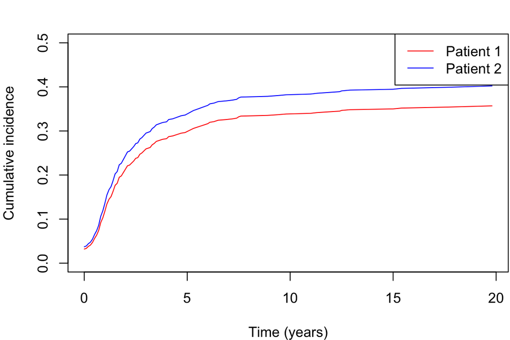

```r
par(mar = c(4, 4, 2, 0.1))
plot(CIF_hat[, 1],
     CIF_hat[, 2],
     type = "l",
     col = "red",
     ylim = c(0, 0.5),
     xlab = "Time (years)",
     ylab = "Cumulative incidence")

lines(CIF_hat[, 1], CIF_hat[, 4], col="blue")
legend("topright", legend = c("Patient 1", "Patient 2"),
       lty = c(1,1), col = c("red", "blue"))
```

> *NOTE:* Using `cmprsk` it is not straightforward to do predictions at a specific time point beyond the unique time-points present in the training data.

## `riskRegression`

This R package acts as a wrapper of the `crr()` function described above. However, it permits directly specifying the model through the formula argument, where we use `Hist()` to obtain the the response variable. When the cause argument is not passed, the default is 1.

Below we confirm that estimated coefficients are identical to those obtained with `cmprsk` package and the interpretation is the same.

```r
library(prodlim)         # for Hist()
library(riskRegression)

FG_riskregression <- FGR(formula = Hist(time, status) ~
                           age +
                           sex +
                           trtgiven +
                           medwidsi +
                           extranod +
                           clinstg,
                          data = hd_train,
                          cause = 1)
print(FG_riskregression)
```

```
#>
#> Right-censored response of a competing.risks model
#>
#> No.Observations: 692
#>
#> Pattern:
#>
#> Cause     event right.censored
#>   1         233              0
#>   2         108              0
#>   unknown     0            351
#>
#>
#> Fine-Gray model: analysis of cause 1
#>
#> Competing Risks Regression
#>
#> Call:
#> FGR(formula = Hist(time, status) ~ age + sex + trtgiven + medwidsi +
#>     extranod + clinstg, data = hd_train, cause = 1)
#>
#>               coef exp(coef) se(coef)      z p-value
#> age         0.0136     1.014  0.00436  3.109 0.00190
#> sexM        0.0705     1.073  0.13587  0.519 0.60000
#> trtgivenRT  0.7030     2.020  0.20557  3.419 0.00063
#> medwidsiN  -0.0594     0.942  0.25960 -0.229 0.82000
#> medwidsiS  -0.4029     0.668  0.25558 -1.577 0.11000
#> extranodY   0.3162     1.372  0.25042  1.263 0.21000
#> clinstg2    0.3376     1.402  0.15373  2.196 0.02800
#>
#>            exp(coef) exp(-coef)  2.5% 97.5%
#> age            1.014      0.987 1.005  1.02
#> sexM           1.073      0.932 0.822  1.40
#> trtgivenRT     2.020      0.495 1.350  3.02
#> medwidsiN      0.942      1.061 0.567  1.57
#> medwidsiS      0.668      1.496 0.405  1.10
#> extranodY      1.372      0.729 0.840  2.24
#> clinstg2       1.402      0.714 1.037  1.89
#>
#> Num. cases = 692
#> Pseudo Log-likelihood = -1462
#> Pseudo likelihood ratio test = 33.1  on 7 df,
#>
#> Convergence: TRUE
```

Differently to `cmprsk`,`riskRegression` permits to do predictions of the CIF at a specific time point (e.g. $t=5$ years) for a new dataset (e.g. `hd_test`). Below, we show results for the first 5 subjects in the test set.

```r
FG.prediction <- predict(FG_riskregression, newdata = hd_test,  times = 5)
FG.prediction[c(1:5)]
```

```
#> [1] 0.2964653 0.4056692 0.3361023 0.3202368 0.2351294
```

Because the Fine-Gray model can be recovered when a complementary log-log link function is used in a transformation model (Gerds, Scheike, and Andersen (2012)), we can use `riskRegression()` with `link = "prop"` as shown below:

```r
FG.prop <- riskRegression(formula = Hist(time, status) ~
                            age +
                            sex +
                            trtgiven +
                            medwidsi +
                            extranod +
                            clinstg,
                          data = hd_train,
                          cause = 1,
                          link = "prop")
summary(FG.prop)
```

```
#>
#> riskRegression: Competing risks regression model
#>
#> IPCW estimation. The weights are based on
#> the Kaplan-Meier estimate for the censoring distribution.
#>
#> Link function: 'proportional' yielding sub-hazard ratios (Fine & Gray 1999), see help(riskRegression).
#>
#> Covariates with time-varying effects:
#>
#>  Intercept (numeric)
#>
#> The effects of these variables depend on time.The column 'Intercept' is the baseline risk where all the covariates have value zero
#>
#>      (Intercept)
#> 0.36 "0.0123"
#> 2    "0.0670"
#> 3.8  "0.0906"
#> 6.4  "0.1064"
#> 20   "0.1199"
#>
#> Shown are selected time points, use
#>
#> plot.riskRegression
#>
#> to investigate the full shape.
#>
#>
#> Covariates with time-constant effects:
#>
#>  age (numeric)
#>  sexM (numeric)
#>  trtgivenRT (numeric)
#>  medwidsiN (numeric)
#>  medwidsiS (numeric)
#>  extranodY (numeric)
#>  clinstg2 (numeric)
#>
#> Time constant regression coefficients:
#>
#>      Factor    Coef exp(Coef) StandardError       z         CI_95    Pvalue
#>         age 0.01649   1.01663       0.00431 3.82626 [1.008;1.025] 0.0001301
#>        sexM  0.0133    1.0134        0.1419  0.0939 [0.767;1.338] 0.9251590
#>  trtgivenRT   0.712     2.037         0.217   3.283 [1.332;3.115] 0.0010271
#>   medwidsiN -0.0687    0.9336        0.2768 -0.2481 [0.543;1.606] 0.8040708
#>   medwidsiS  -0.407     0.665         0.274  -1.489 [0.389;1.137] 0.1364193
#>   extranodY   0.231     1.259         0.254   0.908 [0.766;2.071] 0.3637606
#>    clinstg2   0.339     1.403         0.163   2.082 [1.020;1.930] 0.0373014
#>
#>
#> Note: The values exp(Coef) are sub-hazard ratios (Fine & Gray 1999)
```

In this case, `predict()` returns the risk at observed time points for each subject.

```r
prediction.FG.prop  <- predict(FG.prop, newdata = hd_test[c(1, 3), ])
prediction.FG.prop
```

```
#> $time
#>  [1]  0.3550000  0.4926531  0.6303061  0.7679592  0.9056122  1.0432653
#>  [7]  1.1809184  1.3185714  1.4562245  1.5938776  1.7315306  1.8691837
#> [13]  2.0068367  2.1444898  2.2821429  2.4197959  2.5574490  2.6951020
#> [19]  2.8327551  2.9704082  3.2080612  3.3457143  3.4833673  3.6210204
#> [25]  3.7586735  3.9926531  4.1679592  4.3716327  4.5185714  4.7938776
#> [31]  5.0691837  5.3222449  5.5197959  5.6975510  6.0352041  6.2457143
#> [37]  6.4105102  6.6926531  7.1574490  7.4234694  7.5611224  8.8840816
#> [43]  9.5457143 10.6889796 11.4290816 12.4493878 12.8481633 15.0987755
#> [49] 16.7716327 19.8000000
#>
#> $risk
#>            [,1]       [,2]       [,3]       [,4]      [,5]      [,6]      [,7]
#> [1,] 0.04268004 0.05112741 0.06900018 0.08112631 0.1041914 0.1197376 0.1343491
#> [2,] 0.04755392 0.05693691 0.07675695 0.09017895 0.1156515 0.1327773 0.1488413
#>           [,8]      [,9]     [,10]     [,11]     [,12]     [,13]     [,14]
#> [1,] 0.1499184 0.1591504 0.1749583 0.1926217 0.1963322 0.2116438 0.2173892
#> [2,] 0.1659232 0.1760349 0.1933190 0.2125860 0.2166271 0.2332799 0.2395189
#>          [,15]     [,16]     [,17]     [,18]     [,19]     [,20]     [,21]
#> [1,] 0.2192026 0.2274841 0.2326651 0.2339825 0.2442934 0.2492066 0.2574446
#> [2,] 0.2414869 0.2504679 0.2560807 0.2575073 0.2686622 0.2739714 0.2828642
#>          [,22]     [,23]     [,24]     [,25]     [,26]     [,27]     [,28]
#> [1,] 0.2636049 0.2669364 0.2735112 0.2748284 0.2756051 0.2809147 0.2820748
#> [2,] 0.2895066 0.2930961 0.3001744 0.3015916 0.3024271 0.3081360 0.3093827
#>          [,29]     [,30]     [,31]     [,32]     [,33]     [,34]     [,35]
#> [1,] 0.2844348 0.2874550 0.2890380 0.2972745 0.2987909 0.3018743 0.3078412
#> [2,] 0.3119181 0.3151614 0.3168607 0.3256950 0.3273201 0.3306234 0.3370108
#>          [,36]     [,37]     [,38]     [,39]     [,40]     [,41]     [,42]
#> [1,] 0.3109461 0.3144607 0.3161547 0.3170026 0.3199931 0.3229954 0.3246863
#> [2,] 0.3403320 0.3440893 0.3458995 0.3468053 0.3499993 0.3532041 0.3550083
#>          [,43]     [,44]     [,45]     [,46]     [,47]     [,48]     [,49]
#> [1,] 0.3281412 0.3297946 0.3329718 0.3364468 0.3378281 0.3409324 0.3423308
#> [2,] 0.3586930 0.3604558 0.3638414 0.3675423 0.3690128 0.3723161 0.3738036
#>          [,50]
#> [1,] 0.3464244
#> [2,] 0.3781558
#>
#> attr(,"class")
#> [1] "predictedRisk"
```

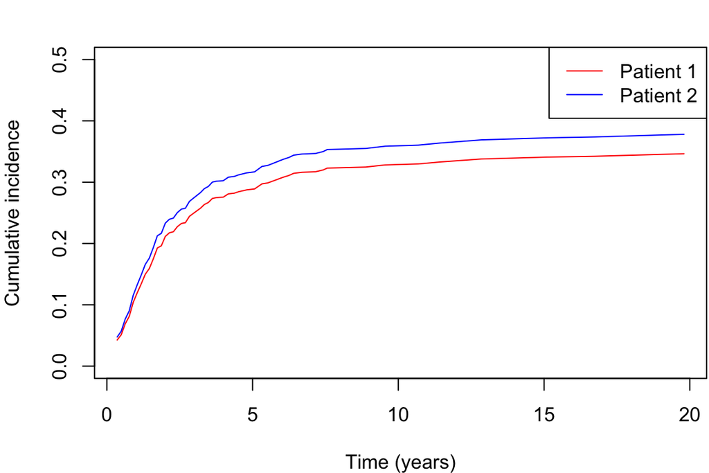

```r
par(mar = c(4, 4, 2, 0.1))
plot(prediction.FG.prop$time,
     prediction.FG.prop$risk[1, ],
     type = "l",
     col = "red",
     ylim = c(0, 0.5),
     xlab = "Time (years)",
     ylab = "Cumulative incidence")
lines(prediction.FG.prop$time, prediction.FG.prop$risk[2, ], col="blue")
legend("topright", legend = c("Patient 1", "Patient 2"),
       lty = c(1,1), col = c("red", "blue"))
```

# Sparse regression

**CoxBoost was deleted from CRAN**

# Pseudo-values

> *NOTE:* the package have been updated with respect to the code shown in Klein et al. (2008). The user is referred to the package documentation for the function.**

We define a time point grid of $M=7$ equally spaced points at which we will compute the pseudo-values. Pseudo-observations are computed with the `pseudoci()` function for both competing events. Below, we only consider relapse (cause 1).

```r
library(pseudo)

cutoffs <- c(5, 10, 15, 20, 25, 30, 35)

pseudo <- pseudoci(hd_train$time,
                   hd_train$status,
                   tmax = cutoffs)$pseudo$cause1     # we only consider cause 1
dim(pseudo)
```

```
#> [1] 692   7
```

`pseudo` contains the pseudo-values of the 692 patients (rows) at the 7 different time points (columns) for relapse.

The following code will merge the pseudo-values with our train dataset.

```r
merged_dataset <- NULL
for (j in seq_len(ncol(pseudo))) {
    merged_dataset <- rbind(merged_dataset,
                            cbind(hd_train,
                                  pseudo = pseudo[, j],
                                  tpseudo = cutoffs[j],
                                  id = seq_len(nrow(hd_train))))
}

merged_dataset <- merged_dataset[order(merged_dataset$id), ]
merged_dataset$tpseudo <- as.factor(merged_dataset$tpseudo)
```

We will now fit a generalised linear model using `geese()` function from R package `geepack`. We set `mean.link = "cloglog"` to use a complementary log-log link in order to recover Fine-Gray approach (alternative link functions can also be used, e.g. Klein et al. (2008) explored a logistic link function).

```r
library(geepack)

fit_pseudo <- geese(pseudo ~
                      tpseudo +
                      age +
                      sex +
                      trtgiven +
                      medwidsi +
                      extranod +
                      clinstg - 1,
                    data = merged_dataset,
                    id = id,
                    jack = TRUE,
                    scale.fix = TRUE,
                    family = gaussian,
                    mean.link = "cloglog",
                    corstr = "independence")
summary(fit_pseudo)
```

```
#>
#> Call:
#> geese(formula = pseudo ~ tpseudo + age + sex + trtgiven + medwidsi +
#>     extranod + clinstg - 1, id = id, data = merged_dataset, family = gaussian,
#>     mean.link = "cloglog", scale.fix = TRUE, corstr = "independence",
#>     jack = TRUE)
#>
#> Mean Model:
#>  Mean Link:                 cloglog
#>  Variance to Mean Relation: gaussian
#>
#>  Coefficients:
#>               estimate      san.se      ajs.se       wald            p
#> tpseudo5   -2.09156255 0.304444865 0.306480315 47.1980882 6.416312e-12
#> tpseudo10  -1.93467529 0.303505493 0.305580169 40.6333901 1.836417e-10
#> tpseudo15  -1.89317851 0.304132302 0.306209180 38.7487802 4.820113e-10
#> tpseudo20  -1.87334298 0.304302051 0.306377963 37.8987455 7.451314e-10
#> tpseudo25  -1.87334298 0.304302051 0.306377963 37.8987455 7.451314e-10
#> tpseudo30  -1.87334298 0.304302051 0.306377963 37.8987455 7.451314e-10
#> tpseudo35  -1.87334298 0.304302051 0.306377963 37.8987455 7.451314e-10
#> age         0.01187650 0.004197232 0.004222343  8.0066538 4.660578e-03
#> sexM        0.04476491 0.135461219 0.135829640  0.1092057 7.410502e-01
#> trtgivenRT  0.71119910 0.202461201 0.203996253 12.3395346 4.434656e-04
#> medwidsiN  -0.11158758 0.262221132 0.265533993  0.1810908 6.704375e-01
#> medwidsiS  -0.44758745 0.258239410 0.261306977  3.0040749 8.305538e-02
#> extranodY   0.21683169 0.236076424 0.241292660  0.8436072 3.583671e-01
#> clinstg2    0.27668796 0.155666142 0.155970837  3.1593097 7.549510e-02
#>
#> Scale is fixed.
#>
#> Correlation Model:
#>  Correlation Structure:     independence
#>
#> Returned Error Value:    0
#> Number of clusters:   692   Maximum cluster size: 7
```

Covariate effects are shown below and are interpreted as logarithms of sub-distribution hazard ratios. Because we used a complementary log-log link function, we observe that the estimated effects are akin to those obtained in the previous section.

```r
exp(fit_pseudo$beta)
```

```
#>   tpseudo5  tpseudo10  tpseudo15  tpseudo20  tpseudo25  tpseudo30  tpseudo35
#>  0.1234940  0.1444712  0.1505924  0.1536093  0.1536093  0.1536093  0.1536093
#>        age       sexM trtgivenRT  medwidsiN  medwidsiS  extranodY   clinstg2
#>  1.0119473  1.0457820  2.0364317  0.8944131  0.6391683  1.2421350  1.3187548
```

The estimated coefficients for the selected time points can be used to estimate the CIF, but this is only possible at the time-points used in the `cutoffs` grid.

# Direct binomial

Binomial modelling approach can be fitted using the `timereg` R package.

To fit the model, we should first use the `Event()` function to obtain the response variable to be used in the formula argument of the `comp.risk()` function. The cause of interest must be explicitly defined through the cause argument. The function supports several models. Here we focus on recovering the Fine-Gray approach.

```r
library(timereg)

fit_DB <- comp.risk(Event(time, status) ~
                      const(age) + # const for time-invariant
                      const(sex) +
                      const(trtgiven) +
                      const(medwidsi) +
                      const(extranod) +
                      const(clinstg),
                    data = hd_train,
                    cause = 1,
                    n.sim = 5000,
                    model = "prop",       # Fine-Gray
                    resample.iid = 1)
summary(fit_DB)
```

```
#> Competing risks Model
#>
#> Test for nonparametric terms
#>
#> Test for non-significant effects
#>             Supremum-test of significance p-value H_0: B(t)=0
#> (Intercept)                          11.9                   0
#>
#> Test for time invariant effects
#>                   Kolmogorov-Smirnov test p-value H_0:constant effect
#> (Intercept)                          1.63                           0
#>                     Cramer von Mises test p-value H_0:constant effect
#> (Intercept)                          3.79                           0
#>
#> Parametric terms :
#>                     Coef.      SE Robust SE       z   P-val lower2.5%
#> const(age)         0.0165 0.00431   0.00431  3.8300 0.00013   0.00805
#> const(sex)M        0.0133 0.14200   0.14200  0.0939 0.92500  -0.26500
#> const(trtgiven)RT  0.7120 0.21700   0.21700  3.2800 0.00103   0.28700
#> const(medwidsi)N  -0.0687 0.27700   0.27700 -0.2480 0.80400  -0.61200
#> const(medwidsi)S  -0.4070 0.27400   0.27400 -1.4900 0.13600  -0.94400
#> const(extranod)Y   0.2310 0.25400   0.25400  0.9080 0.36400  -0.26700
#> const(clinstg)2    0.3390 0.16300   0.16300  2.0800 0.03730   0.01950
#>                   upper97.5%
#> const(age)            0.0249
#> const(sex)M           0.2920
#> const(trtgiven)RT     1.1400
#> const(medwidsi)N      0.4740
#> const(medwidsi)S      0.1300
#> const(extranod)Y      0.7290
#> const(clinstg)2       0.6580
#>
```

According to the summary output, the covariate effects associated to age, treatment and clinical stage are significant. Below, we show estimated hazard ratios.

```r
knitr::kable(round(exp(fit_DB$gamma), 4), col.names = c("Exp coef"))
```

|  | Exp coef |
| --- | --- |
| const(age) | 1.0166 |
| const(sex)M | 1.0134 |
| const(trtgiven)RT | 2.0372 |
| const(medwidsi)N | 0.9336 |
| const(medwidsi)S | 0.6654 |
| const(extranod)Y | 1.2593 |
| const(clinstg)2 | 1.4033 |

In order to do predictions of the CIF, we use the `predict()` function. The default makes predictions at all observed time points. Below we show estimated incidence for the first (red) and second (blue) patients in the tests set:

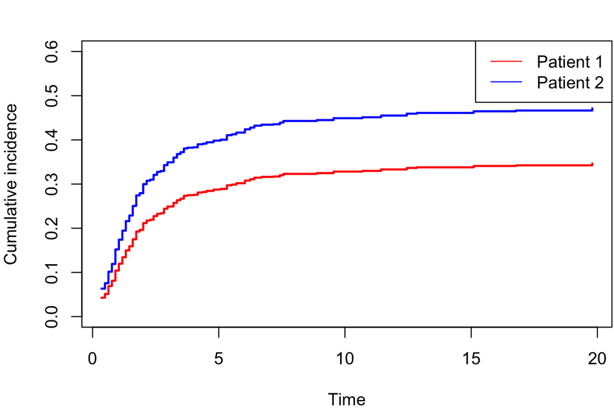

```r
par(mar = c(4, 4, 2, 0.1))
pred_DB <- predict.timereg(fit_DB,
                           newdata = as.data.frame(hd_test[1:2,2:7]), se = 0)
plot(pred_DB,
     multiple = 1,
     col = c("red", "blue"),
     ylim = c(0, 0.6),
     ylab = "Cumulative incidence")
legend("topright", legend = c("Patient 1", "Patient 2"),
       lty = c(1,1), col = c("red", "blue"))
```

In addition, one can also makes predictions at a specific time through the argument `times`. Absolute risk predictions at time $t=5$ for the first 5 patients are shown:

```r
pred_DB.t <- predict.timereg(fit_DB, newdata = hd_test[1:5, 2:7], times = 5)
c(pred_DB.t$P1)
```

```
#> [1] 0.2874550 0.3983123 0.3151614 0.2977388 0.2162792
```

`timereg` permits fitting the model time varying effects. For example, the following code includes a time-dependent effect for `trtgiven`.

```r
fit_DBtime <- comp.risk(Event(time, status) ~
                          const(age) +
                          const(sex) +
                          trtgiven +
                          const(medwidsi) +
                          const(extranod) +
                          const(clinstg),
                        data = hd_train,
                        cause = 1,
                        model = "prop", # Fine-Gray
                        resample.iid = 1,
                        n.sim = 100)
summary(fit_DBtime)
```

```
#> Competing risks Model
#>
#> Test for nonparametric terms
#>
#> Test for non-significant effects
#>             Supremum-test of significance p-value H_0: B(t)=0
#> (Intercept)                          8.60                   0
#> trtgivenRT                           3.62                   0
#>
#> Test for time invariant effects
#>                   Kolmogorov-Smirnov test p-value H_0:constant effect
#> (Intercept)                         1.220                         0.0
#> trtgivenRT                          0.548                         0.1
#>                     Cramer von Mises test p-value H_0:constant effect
#> (Intercept)                         2.470                        0.00
#> trtgivenRT                          0.114                        0.42
#>
#> Parametric terms :
#>                    Coef.      SE Robust SE       z    P-val lower2.5%
#> const(age)        0.0165 0.00431   0.00431  3.8200 0.000131   0.00805
#> const(sex)M       0.0129 0.14200   0.14200  0.0912 0.927000  -0.26500
#> const(medwidsi)N -0.0684 0.27700   0.27700 -0.2470 0.805000  -0.61100
#> const(medwidsi)S -0.4080 0.27300   0.27300 -1.4900 0.136000  -0.94300
#> const(extranod)Y  0.2270 0.25400   0.25400  0.8940 0.371000  -0.27100
#> const(clinstg)2   0.3390 0.16300   0.16300  2.0800 0.037400   0.01950
#>                  upper97.5%
#> const(age)           0.0249
#> const(sex)M          0.2910
#> const(medwidsi)N     0.4750
#> const(medwidsi)S     0.1270
#> const(extranod)Y     0.7250
#> const(clinstg)2      0.6580
#>
```

# Dependent Dirichlet processes

> *NOTE:* `DPWeibull` is not available on CRAN because a dependency, `binaryLogic`, was removed from CRAN as the maintainer’s email address is no longer accessible**

The formula definition uses `Hist()`.

```r
library(DPWeibull)
library(prodlim) # for Hist() function
set.seed(1)
fit_DDP <- dpweib(Hist(time, status) ~
                    age +
                    sex +
                    trtgiven +
                    medwidsi +
                    extranod +
                    clinstg ,
                  data = hd_train,
                  comp = TRUE,
                  burnin = 1000,
                  iteration = 5000,
                  predtime = seq(from = min(hd_train$time),
                                 to = max(hd_train$time),
                  length =  40))
```

```r
summary(fit_DDP)
```

```
#> $age
#>                            1/4 Observation Time 1/2 Observation Time
#> Time                               8.2869230769        17.4912820513
#> Estimated Log Hazard Ratio         0.0004075125         0.0004989918
#> Upper Credible Interval            0.0013324862         0.0064448482
#> Lower Credible Interval           -0.0008071562        -0.0022202772
#>                            3/4 Observation Time Observation Time
#> Time                              26.6956410256    35.9000000000
#> Estimated Log Hazard Ratio         0.0004580767     0.0004765798
#> Upper Credible Interval            0.0045218312     0.0060484606
#> Lower Credible Interval           -0.0045255286    -0.0047885991
#>
#> $sexM
#>                            1/4 Observation Time 1/2 Observation Time
#> Time                                 8.28692308           17.4912821
#> Estimated Log Hazard Ratio           0.09835154            0.3123080
#> Upper Credible Interval              0.74064599            2.3958925
#> Lower Credible Interval             -0.51139794           -0.8150875
#>                            3/4 Observation Time Observation Time
#> Time                                 26.6956410       35.9000000
#> Estimated Log Hazard Ratio            0.2547861        0.1771222
#> Upper Credible Interval               2.2806902        2.3066240
#> Lower Credible Interval              -1.4200622       -2.1698395
#>
#> $trtgivenRT
#>                            1/4 Observation Time 1/2 Observation Time
#> Time                                  8.2869231           17.4912821
#> Estimated Log Hazard Ratio            0.3990038            0.4314623
#> Upper Credible Interval               1.3166761            2.1286092
#> Lower Credible Interval              -0.3284915           -1.0976295
#>                            3/4 Observation Time Observation Time
#> Time                                 26.6956410       35.9000000
#> Estimated Log Hazard Ratio            0.4555331        0.4129776
#> Upper Credible Interval               2.6552012        3.2700930
#> Lower Credible Interval              -1.3453753       -1.4295031
#>
#> $medwidsiN
#>                            1/4 Observation Time 1/2 Observation Time
#> Time                                 8.28692308         17.491282051
#> Estimated Log Hazard Ratio           0.02103338          0.005156996
```

[output cut: 31 more lines]

```
#>
#> $clinstg2
#>                            1/4 Observation Time 1/2 Observation Time
#> Time                                  8.2869231           17.4912821
#> Estimated Log Hazard Ratio            0.2354166            0.3707382
#> Upper Credible Interval               0.8419519            1.9958346
#> Lower Credible Interval              -0.3761483           -1.2942655
#>                            3/4 Observation Time Observation Time
#> Time                                 26.6956410       35.9000000
#> Estimated Log Hazard Ratio            0.4933547        0.5156446
#> Upper Credible Interval               2.5626363        2.8857889
#> Lower Credible Interval              -1.2456624       -1.4007764
#>
#> attr(,"class")
#> [1] "summary.ddpcomp"
```

Note that in order to make valid inferences one should ensure that convergence was achieved. One can explore trace plots of the estimated parameters using the `coda` library. This will help us to determine if the MCMC parameters employed when fitting the model should be modified. For instance, below we show trace plots of $\alpha$ and $\lambda$ for patient 1, where we observe that the chains for $\alpha$ do not appear to have converged and therefore a larger number of MCMC iterations should be used.

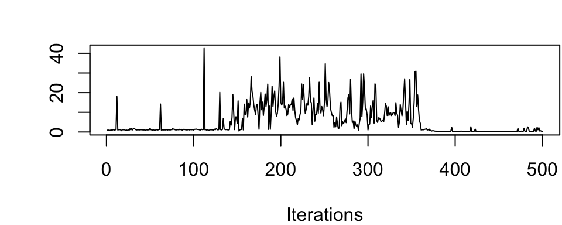

```r
library(coda)
par(mar = c(4, 4, 2, 0.1))
traceplot(as.mcmc(fit_DDP$alpharec1[, 1]))
```

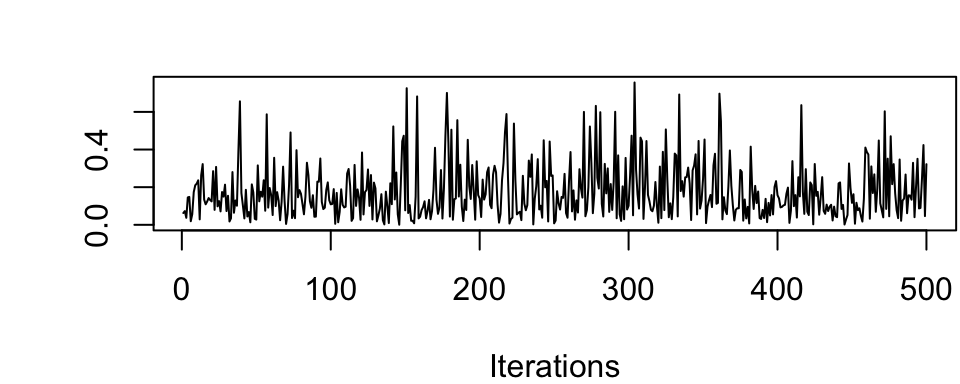

```r
traceplot(as.mcmc(fit_DDP$lambda0rec1[, 1]))
```

Below, we illustrate how to do predictions with `DPWeibull`. First, we show how to estimate the CIF for two subjects in the test set at all observed event times.

```r
par(mar = c(4, 4, 2, 0.1))

pred_DDP <- predict(fit_DDP, newdata = as.data.frame(hd_test[c(1, 2), 2:7]))
```

Note that `pred_DDP` contains posterior samples for the 2 subjects at observed event times, as well as posterior estimated and credible intervals.

Below, we show the estimated CIF curves for patient 1 (red) and 2 (blue).

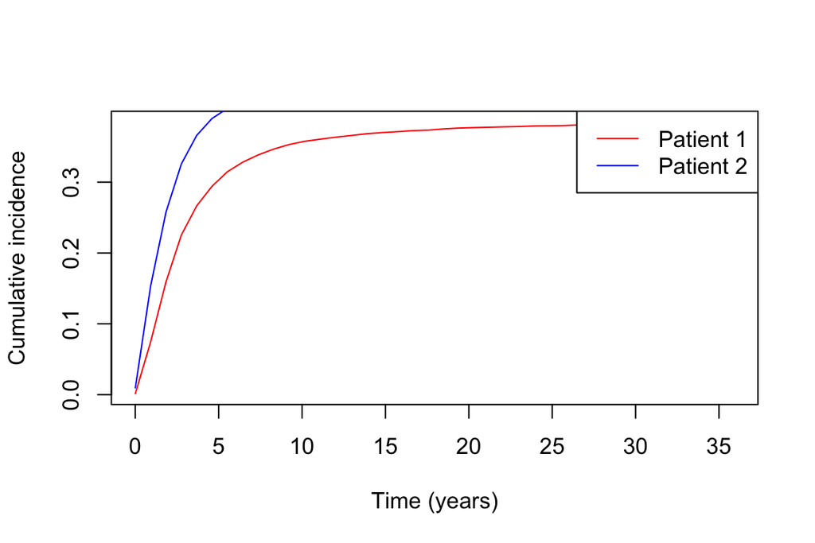

```r
plot(pred_DDP$tpred,
     pred_DDP$Fpred[1, ],
     type = "l",
     col = "red",
     xlab = "Time (years)",
     ylab = "Cumulative incidence")
lines(pred_DDP$tpred, pred_DDP$Fpred[2, ], col="blue")
legend("topright", legend = c("Patient 1", "Patient 2"),
       lty = c(1,1), col = c("red", "blue"))
```

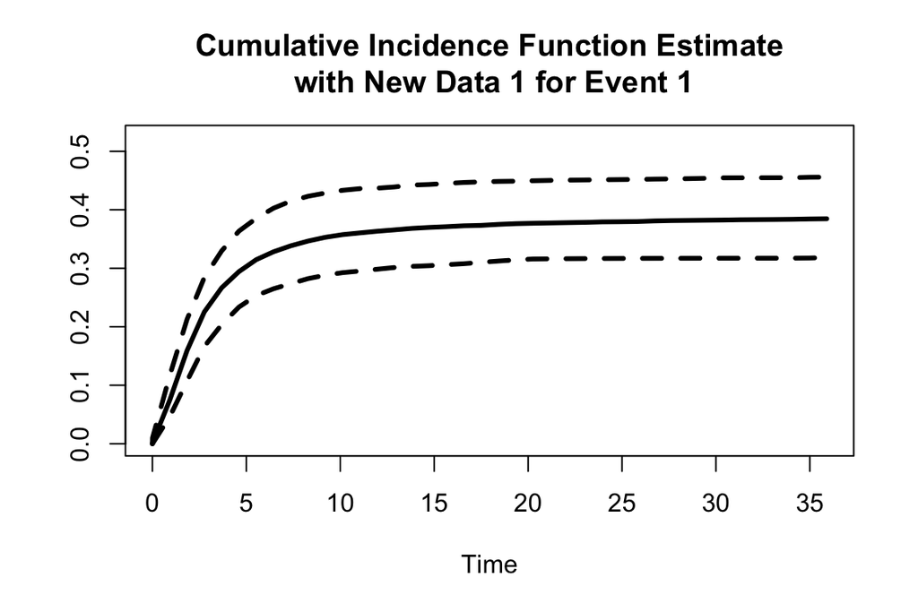

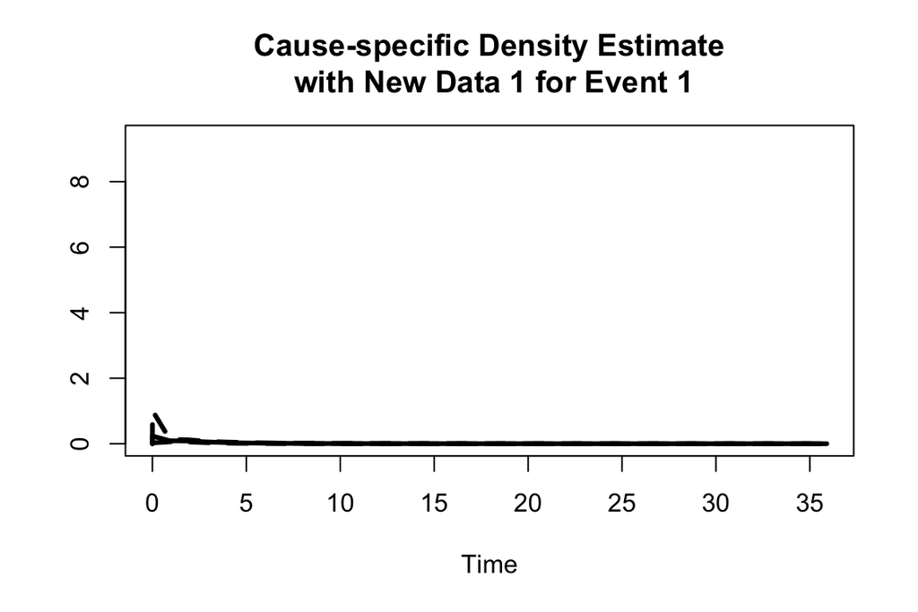

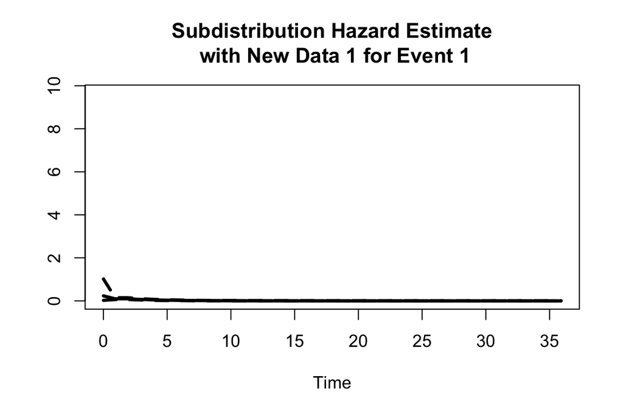

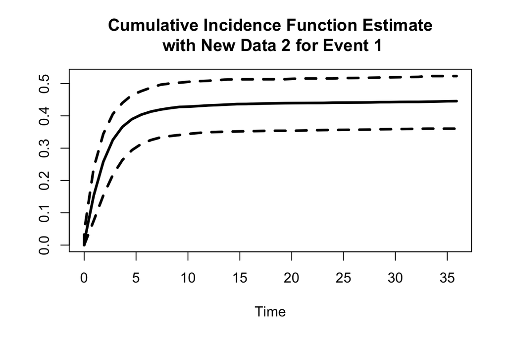

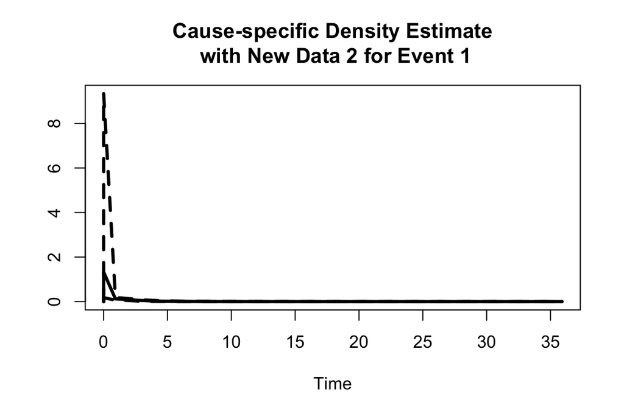

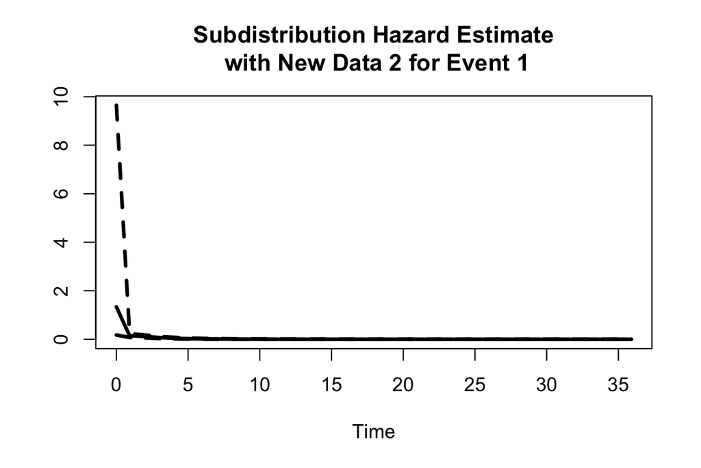

```r
plot(pred_DDP)
```

In addition, we can also make predictions at a specific time point, e.g. $t=5$. Below, we show the estimated risk for the first 5 subjects in the test data set:

```r
pred_DDP.t <- predict(fit_DDP,
                      newdata = as.data.frame(hd_test[1:5, 2:7]), tpred = 5)
pred_DDP.t$Fpred
```

```
#>           [,1]
#> [1,] 0.3039949
#> [2,] 0.3974754
#> [3,] 0.3115905
#> [4,] 0.3160624
#> [5,] 0.2395576
```

# References

Gerds, Thomas A, Thomas H Scheike, and Per K Andersen. 2012. “Absolute Risk Regression for Competing Risks: Interpretation, Link Functions, and Prediction.” *Statistics in Medicine* 31 (29): 3921–30.

Klein, John P., Mette Gerster, Per Kragh Andersen, Sergey Tarima, and Maja Pohar Perme. 2008. “SAS and r Functions to Compute Pseudo-Values for Censored Data Regression.” *Comput. Methods Prog. Biomed.* 89 (3): 289–300. https://doi.org/10.1016/j.cmpb.2007.11.017.

Pintilie, Melania. 2006. *Competing Risks: A Practical Perspective*. John Wiley & Sons.